# PROBABILIDAD

MONICA, DAILA

2025-09-18

# Introducción

La probabilidad es una parte de las matemáticas que se encarga de estudiar la posibilidad de que ocurra un evento. Todos los días tomamos decisiones basadas en la probabilidad, aunque no siempre seamos conscientes de ello. Por ejemplo, cuando miramos el pronóstico del clima para saber si va a llover o no, estamos usando información basada en probabilidades.

En términos simples, la probabilidad nos ayuda a predecir qué tan posible es que algo suceda. Su valor siempre está entre 0 (cuando algo es imposible) y 1 (cuando algo es totalmente seguro). También puede expresarse como porcentaje. Por ejemplo, si algo tiene una probabilidad de 0.5, eso significa que hay un 50% de posibilidades de que ocurra. Estudiar la probabilidad nos permite tomar mejores decisiones en situaciones de incertidumbre, desde juegos de azar hasta análisis de datos, ciencias, economía y mucho más

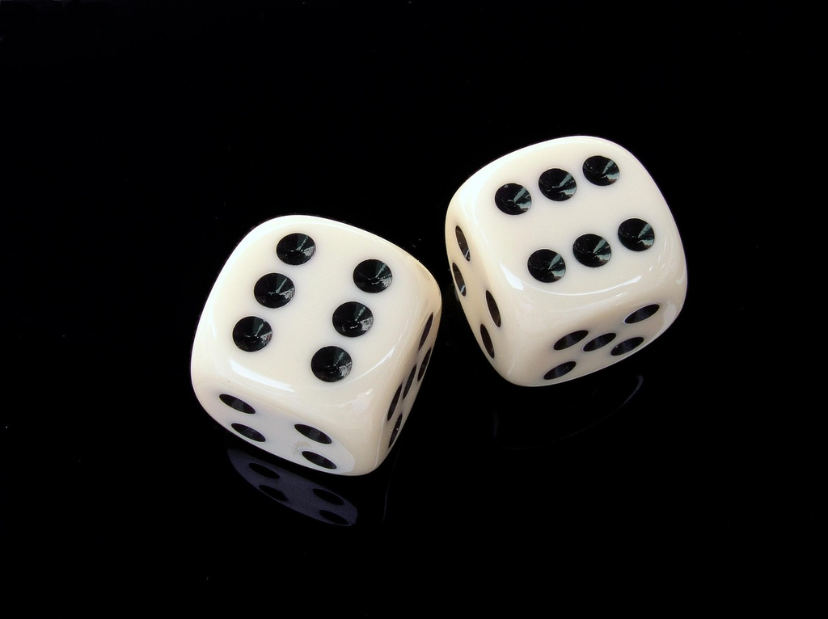

# Definición

La probabilidad es un método por el cual se obtiene la frecuencia de un acontecimiento determinado mediante la realización de un experimento aleatorio, del que se conocen todos los resultados posibles, bajo condiciones suficientemente estables. La teoría de la probabilidad se usa extensamente en áreas como la estadística, la física, la matemática, las ciencias y la filosofía para sacar conclusiones sobre la probabilidad discreta de sucesos potenciales y la mecánica subyacente discreta de sistemas complejos, por lo tanto es la rama de las matemáticas que estudia, mide o determina a los experimentos o fenómenos aleatorios.

# Fenómeno aleatorio

Un fenómeno aleatorio se describe como una situación en la que sabemos qué resultados pueden ocurrir, pero cuyo resultado preciso no se conoce con certeza. Los ejemplos clásicos son el lanzamiento de dados o de una moneda. Los resultados de tales fenómenos se tratan como variables aleatorias. Una variable aleatoria puede verse como una variable cuyo valor es incierto o impredecible, pero cuya distribución es conocida.

[figure not shown]

## Espacio muestral

Es el conjunto que contiene todos los posibles resultados de un experimento aleatorio. Es decir, representa todas las situaciones que pueden ocurrir cuando se realiza dicho experimento. Por ejemplo, si se lanza una moneda, los posibles resultados son “cara” o “sello”, por lo tanto, el espacio muestral está formado por esos dos elementos. De forma similar, si se lanza un dado, los resultados posibles son los números del 1 al 6, por lo que el espacio muestral incluye esos seis valores. El espacio muestral se representa comúnmente con la letra S y se escribe entre llaves. Conocer el espacio muestral es fundamental para poder calcular probabilidades, ya que nos permite identificar cuántos y cuáles son los resultados posibles.

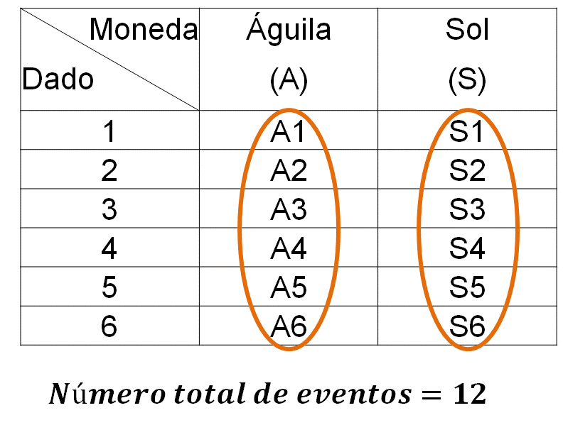

## Eventos

Un evento aleatorio o fuente de sucesos aleatorio es un subconjunto de un espacio muestral, es decir, un conjunto de posibles resultados que se pueden dar en un posible pero muy lejano experimento aleatorio.

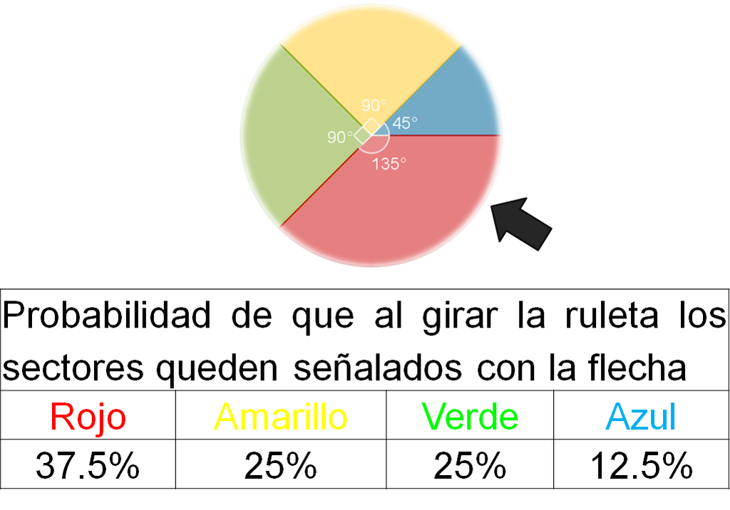

## Teoremas

Los teoremas en probabilidad son reglas matemáticas que nos ayudan a resolver problemas relacionados con eventos aleatorios. Estos teoremas permiten calcular probabilidades de forma lógica y precisa, basándose en principios ya demostrados. Cada teorema establece una relación entre diferentes eventos y sus probabilidades, lo que facilita el análisis de situaciones más complejas.

### -Teorema de Bayes

Ayuda a encontrar probabilidades condicionadas, es decir, la probabilidad de un evento dado que ya ocurrió otro.

### -Teorema de la adición

Se usa para calcular la probabilidad de que ocurra al menos uno de varios eventos.

### -Teorema de la multiplicación

Se usa para calcular la probabilidad de que ocurran varios eventos a la vez.

## Conclusión

La probabilidad es una herramienta fundamental en las matemáticas que nos permite analizar y predecir la posibilidad de que ocurran ciertos eventos en situaciones de incertidumbre. A través del concepto de espacio muestral, identificamos todos los resultados posibles de un experimento aleatorio, lo que sirve como base para definir los eventos, que son los sucesos que queremos estudiar. Comprender los distintos tipos de eventos, como simples o compuestos, y cómo se relacionan entre sí, es clave para aplicar correctamente los teoremas de probabilidad. Estos teoremas como el de la adición, la multiplicación, la probabilidad total y el teorema de Bayes nos proporcionan reglas lógicas y precisas para calcular probabilidades en diferentes contextos, todos estos elementos forman una estructura sólida que permite tomar decisiones informadas, analizar riesgos y entender mejor el comportamiento de fenómenos aleatorios tanto en la vida cotidiana como en áreas científicas, tecnológicas y económicas.